# Detectar Distribuciones

En ocasiones queremos conocer que tipo de distribución tiene unos datos, mas que considerar si son normales, **¿Que distribución se ajusta?**

Primero es importante tener un panorama de las distribuciones conocidas

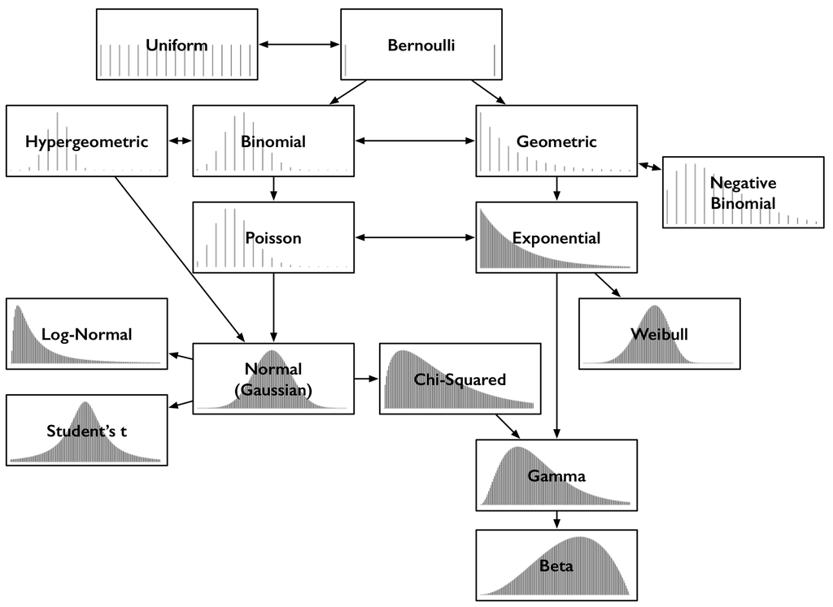

## ¿Cuales hay?

Estas son algunas de las distribuciónes existentes, cada una con ocurrencias distintas y con características propias, algunas son similares como la **Normal** y la **Student**, otras que no parecen tener nada que ver.

A simple vista parece fácil definir que distribución puede ajustarse a nuestros datos, pero ya en la práctica es complicado.

Las características que mas se destacan son dos, la **curtosis** y la **asimetría**.

### Curtosis

Es el grado de concentración que tiene los valores al rededor de la zona central de la distribución de frecuencias.

[figure not shown]

### Asímetría

La asimetría es la medida que indica que tanto se distribuyen los datos de una variable respecto a la media aritmética.

- Cuando $\bar{X} < MD$ donde $\bar{X}$ es la media y MD es la mediana se considera la distribución con asimetría a la izquiera , asimetría negativa o **asimetría de cola izquiera** (puede ser mas intuitivo considerar la *cola* para nombrar la distribución).
- Cuando $\bar{X} > MD$ la distribución se considera asimétrica a la derecha, con asimetría positiva o **asimetría de cola derecha**.

[figure not shown]

## ¿Como lo aplicamos?

El siguiente paso sería usar las características de asimetría y curtosis para determinar la distribución de los valores que revisamos. Pero eso implicaría calcular uno o dos coefientes para determinar la asimetría y uno mas para la kurtosis. Para simplificar el proceso podemos usar el paquete `fitdistrplus()` que simplifica la tarea e incluso aplica técnicas de resampleo para mejorar el pronostico.

Considerando un dataset como este:

```r
head(comparar.distribuciones)
```

|  | tipo | valores |
| --- | --- | --- |
| 1 | D1 | 99.71829 |
| 2 | D1 | 99.46620 |
| 3 | D1 | 100.35588 |
| 4 | D1 | 101.83544 |
| 5 | D1 | 102.33002 |
| 6 | D1 | 99.02288 |

Con la siguiente estructura:

```r
str(comparar.distribuciones)
```

```
'data.frame':   400 obs. of  2 variables:
 $ tipo   : Factor w/ 5 levels "D1","D2","D3",..: 1 1 1 1 1 1 1 1 1 1 ...
 $ valores: num  99.7 99.5 100.4 101.8 102.3 ...
```

Al graficar las distribuciones vemos:

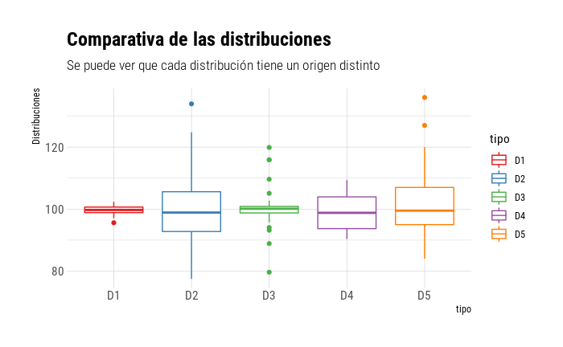

Si revisamos los histogramas:

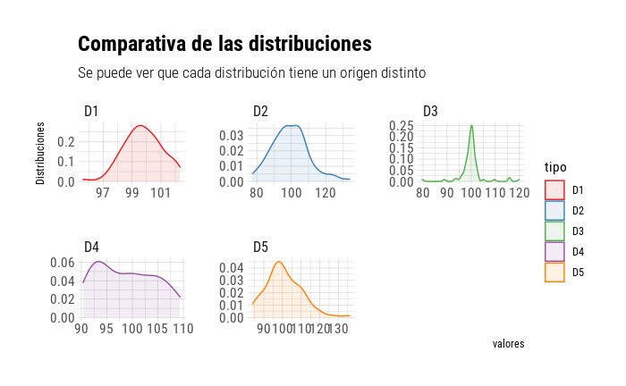

## Determinemos la distribución D1

### Cargamos la librería

```r
library(fitdistrplus)
```

### Segmentamos D1

```r
distribucion.D1 <- comparar.distribuciones[comparar.distribuciones$tipo == "D1",]
```

Con los valores segmentamos podemos usar la función `descdist()`

```
summary statistics
------
min:  95.60148   max:  102.33
median:  99.73089
mean:  99.75857
estimated sd:  1.326959
estimated skewness:  -0.2081456
estimated kurtosis:  3.140256
```

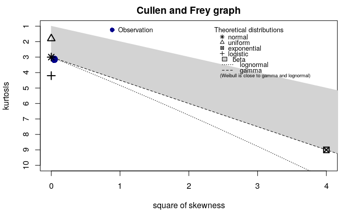

```r
descdist(distribucion.D1$valores)
```

Los símbolos que se muestran definen algunas de las distribuciones, que este paquete puede ajustar, ademas tenemos las bandas que muestran áreas que corresponderían a otras distribuciones. El **punto** de nuestros valores muestra la posición de nuestros valores derivado de sus características y podemos definir que distribución es la que mejor se ajusta nuestros valores dependiendo de la proximidad con los símbolos o su posición en las bandas dibujadas.

En este caso en específico podemos ver que el punto casí se encuentra cercano a una distribución normal(**asterisco**).

Esta función permite aplicar muchos muestreos sobre nuestros valores y a partir de eso mejorar nuestra busqueda.

```
summary statistics
------
min:  95.60148   max:  102.33
median:  99.73089
mean:  99.75857
estimated sd:  1.326959
estimated skewness:  -0.2081456
estimated kurtosis:  3.140256
```

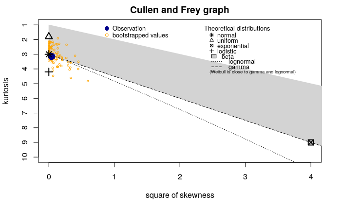

```r
descdist(distribucion.D1$valores, boot = 100)
```

Cada uno de los ensayos generados en cada muestreo se dibuja en amarillo y nos da una idea de como subconjuntos de los datos se estarían representando en este gráfico.

### Repitamos el ejercicio

```
summary statistics
------
min:  77.49023   max:  133.9382
median:  98.89129
mean:  99.44504
estimated sd:  10.73244
estimated skewness:  0.5340738
estimated kurtosis:  3.787965
```

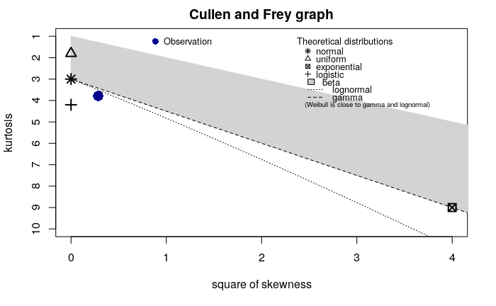

```r
distribucion.D2 <- comparar.distribuciones[comparar.distribuciones$tipo == "D2",]
descdist(distribucion.D2$valores)
```

### Problemas

Para algunas distribuciones esta aproximación puede fallar, pero aún con esto tenemos información para buscar la distribución a la que corresponde o simplemente evitar asumir una la normalidad en una distribución.

```
summary statistics
------
min:  79.65246   max:  119.8836
median:  100.1185
mean:  100.0847
estimated sd:  4.781708
estimated skewness:  0.7005692
estimated kurtosis:  12.49216
```

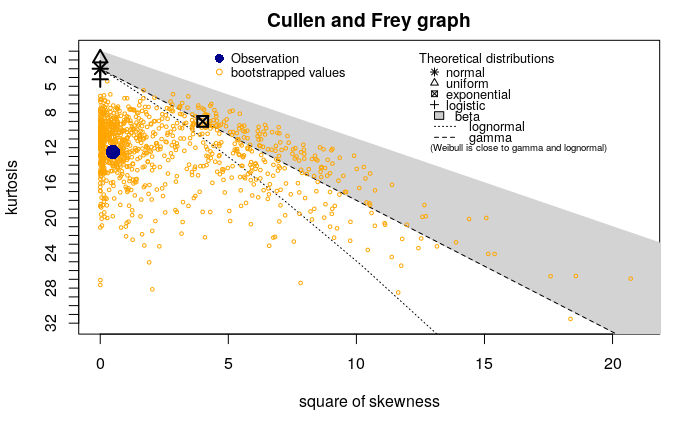

```r
descdist(distribucion.D3$valores, boot = 1000)
```

[output not shown]